# Feeling Thermometers and Affective Polarization

Nobody started liking their own side more

Democracy’s Data

Last updated September 13, 2026 at 10:53a EDT

*Americans hate the other party more than ever.* You have heard the claim, and it has a number behind it. Since 1978 the American National Election Studies — ANES, the academic survey of American voters run by the University of Michigan and Stanford University — has asked people to rate the two parties on a **feeling thermometer**: a hundred is warm, nought is cold, fifty is neither. Take a partisan, someone who identifies with one of the parties. Subtract their rating of the other party (the *out-party*, in the jargon) from their rating of their own (the *in-party*) and you have the standard measure of **affective polarization** — dislike across party lines, as distinct from disagreement about policy.[^1]

Here is the number being built, for the first year in the series. In 1978 the average partisan rated their own party 70.6 degrees and the other party 48.0; 70.6 − 48.0 = 22.6 degrees of polarization. That number has more than doubled since, to 49.5 in 2024. The doubling is real. But it is a subtraction, and a subtraction has two halves that the headline cannot see. The distance could be growing because people warmed toward their own side, or because they cooled toward the other. This brief asks the question the number skips: which half moved?

## The test

The measure is the pair of party feeling thermometers in the ANES Time Series Cumulative Data File, 1948–2024, a single table collected by the University of Michigan and Stanford University for the American National Election Studies, which stacks every study since 1948 into one file. It is free, but must be requested through a browser with an account at [electionstudies.org](https://electionstudies.org/data-center/anes-time-series-cumulative-data-file/). The same two questions, in the same words, sit in every study this brief reports — 18 of them across forty-six years. The ANES chapter introduces the cumulative file and its codebook, the document that says what every code in every column means; this brief pulls two columns out of it.

A feeling is the kind of thing only a survey can hold. Nobody registers a temperature toward a party, and no election ever comes along to grade the answer the way a vote count eventually grades a horse-race poll. The question’s construction is therefore not a detail under the measurement — it *is* the measurement. A forty-six-year series on one pair of questions exists only because ANES staff kept asking the same words, study after study, and kept the codes meaning the same thing throughout.

The test is one that arithmetic can settle. Undo the subtraction: compute warmth toward one’s own party and warmth toward the other party separately, year by year, and see which of the two series produced the doubling.

## The data

The cumulative file is one table, one row per interview: 73,745 respondents from 1948 to 2024. Four columns do the work here. `VCF0218` is the thermometer for the Democratic Party and `VCF0224` the one for the Republican Party. `VCF0301` is the seven-point party identification, used to decide which party counts as a respondent’s own. `VCF0009z` is the weight, which counts some answers more than others so that the sample’s mix of ages, races, regions and so on matches the country’s, with the targets taken from the census. Unlike most of this book’s ANES briefs, every average below applies it.

Two numbers in the thermometer columns are not temperatures, and the data does not warn you. The scale everybody describes as nought to a hundred is coded 0 to 97 in this file. It holds 0 ratings of exactly 100, because a hundred is not a code the file uses. What the file does use is `98` for *don’t know* and `99` for *not ascertained*, the interviewer’s term for an answer that was never obtained, and 2,183 and 934 entries carry them. A 98 sits inside the range a reader expects, so it does not look wrong. It looks like somebody who feels very warmly indeed.

That fact lives in the codebook, not the column, and the cost of missing it is measurable. Believe the codes and the country warms by 1.4 degrees: the average rating rises from 51.5 to 53.0. Worse, the codes are not spread evenly across years, so the mistake bends the trend rather than just shifting it. Everything below drops them, along with 20 negative codes.

| Rating | Share of all ratings |
| --- | --- |
| 0 — as cold as possible | 10.1% |
| 50 — the midpoint | 16.1% |
| 85 | 10.5% |
| 97 — the top of the scale | 6.6% |

70.7% of all 97,268 ratings are multiples of ten. The 85s are the tell that this is habit rather than measurement. Nobody feels exactly 85 degrees about a political party, but it is where the hand goes when the answer is “warm, not the maximum.” A number this fine-grained, used this coarsely, still averages perfectly well. It just does not mean what its precision suggests.

The series itself is built from partisans, with leaners — people who call themselves independent but admit to leaning toward a party — counted alongside: the standard choice, and a choice, which the party identification brief shows moving a different headline number by a factor of five. Pure independents, 5,327 of them, have no own party and sit outside every figure here. A study year must carry at least 200 partisans to be reported, which leaves 18 study years between 1978 and 2024. Two small tables come out: `thermometers_by_year.csv`, with each year’s warmth toward one’s own party, toward the other, and the gap; and `out_party_zero.csv`, the share rating the other party at exactly nought.

> **Before you read on, commit to two numbers.** In 1978, partisans rated their own party 70.6 degrees and the other party 48.0. By 2024, what had each of those become? Write both down.

## What it says about democracy

Here is the subtraction, undone.

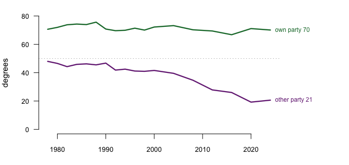

**The top line does not move.** Partisans rated their own party 70.6 degrees in 1978 and 70.1 in 2024, a change of 0.5 of a degree across forty-six years. Through every realignment, every scandal, and every president in between, the feeling of partisans toward their own party has been a flat line.

The bottom line falls off the table. Warmth toward the other party went from 48.0 to 20.6, a drop of 27.4 degrees, and it now sits far below the fifty the scale calls neither warm nor cold. Redo the subtraction with the new readings: 70.1 − 20.6 = 49.5. The first number barely changed; the second did all the work. Put as one number: 98.1% of the movement in the gap is the out-party half. Nobody started liking their own side more. They stopped being able to stand the other one. The gap peaked at 51.9 degrees in 2020, the same year the other party’s rating touched its floor of 19.2.

The averages also hide *how* the fall happened, and it is not everybody sliding down a few degrees.

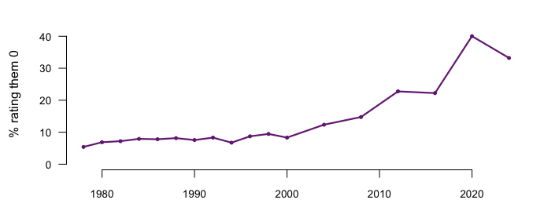

**Figure 2. The share of partisans rating the other party at absolute zero.** One line, because the question is how common the floor became — the average in Figure 1 fell partly because a growing group stopped using the scale and went to its bottom.

In 1978, 5.4% of partisans gave the other party the coldest rating available. In 2024 it was 33.2%. That is a third of partisans choosing the absolute bottom of a 98-position scale, an answer that reads less like a temperature than like a refusal to have one.

This matters for how the country gets described. The single number that gets reported cannot show any of it, because a difference has no memory of which side moved. Two series drifting apart and one series collapsing produce the same gap, and they are different stories about democracy. The first is mutual estrangement; the second is one feeling, out-party dislike, doing all the work.

The gender gap brief runs the same arithmetic on a different question and reaches the same lesson. Ask for the pair. It is one extra number, and it changes the sentence.

## What this brief cannot tell you

**A thermometer reading is not a behaviour.** It is a number somebody said to an interviewer. Nothing here shows anyone refusing a neighbour, a hire, or an in-law over party, and the literature linking affective polarization to behaviour is contested.[^2]

**The object being rated changed.** “The Republican Party” and “the Democratic Party” meant different things in 1978 than in 2024. A respondent rating a party colder may be feeling differently about the same object, or the same about a different one, and the file cannot separate those.

**These are cross-sections, not the same people.** Each study draws a fresh sample, so different respondents answer every year. A falling series can mean individuals changed their minds, or that the people replaced by generational turnover felt differently, and those are different countries. Only a panel — a survey that goes back to the same people — could tell them apart.

**And the series has thin stretches.** A year needs 200 partisans to appear, which leaves 18 study years across forty-six years. The lines connect points that are sometimes several years apart, and the connecting segments are drawn, not measured.

## What you should have learned

- Affective polarization in the ANES is 49.5 degrees, up from 22.6 in 1978, with a peak of 51.9 in 2020.
- The gap is a subtraction, and essentially one half moved: own-party warmth changed 0.5 of a degree while other-party warmth fell 27.4 — 98.1% of the movement is the out-party half.
- Part of the fall is a floor: the share of partisans rating the other party at exactly nought went from 5.4% to 33.2%.
- Two codes in the thermometer columns, 98 and 99, are not temperatures; believing them warms the country by 1.4 degrees and bends the trend.
- The scale is used far more coarsely than it looks: 70.7% of ratings are multiples of ten.

## Extensions

None of these is answered above, and every one can be answered from the tables the Sources section hands over.

- `thermometers_by_year.csv` has `in_party` and `out_party`. Divide one by the other, year by year. When does the other party first earn less than half the warmth of one’s own?
- `thermometers_by_year.csv` has `gap` for every reported year. Work out how much of the total rise arrived in each decade. Is the doubling steady, or does one stretch carry most of it?
- `out_party_zero.csv` has `pct_zero`. Find the year it first passes 20%, and decide whether the climb to a third is a ramp or a staircase.
- `thermometers_by_year.csv` carries `n` for every year. Find the thinnest years, and decide whether the shape of the trend survives without them.

Two stretch ideas point past the spreadsheet. The same ANES file carries thermometers for dozens of other objects: unions, big business, liberals, conservatives. A reader with the cumulative file can test whether coldness rose toward out-groups in general or toward the out-party alone. And the Pew Research Center publishes its own series on partisans holding “very unfavorable” views of the other party, for instance in its 2022 report on partisan hostility (https://www.pewresearch.org/politics/2022/08/09/as-partisan-hostility-grows-signs-of-frustration-with-the-two-party-system/); check whether its timing matches Figure 2’s climb.

## Sources

**Data**

- American National Election Studies. *ANES Time Series Cumulative Data File (1948–2024)*, version of 5 February 2026, CSV distribution `anes_timeseries_cdf_csv_20260205.csv`. Ann Arbor, MI and Palo Alto, CA: University of Michigan and Stanford University. https://electionstudies.org/data-center/anes-time-series-cumulative-data-file/
- ANES. *Time Series Cumulative Data File Codebook*, same release. The meaning of codes 98 and 99 was read out of it rather than assumed.
- The file must be requested through a browser with a free account, and is not redistributed with this book; the ANES chapter describes what it costs to get. Every number above is computed from the two tables below at the moment this document is rendered, and checked against these assertions:

| Check | Passed |
| --- | --- |
| the whole cumulative file arrived | yes |
| there is no value of 100 in a column described as running to 100 | yes |
| the codes that masquerade as warmth are present and worth removing | yes |
| believing the codes warms the country | yes |
| the scale is used far more coarsely than its 98 points allow | yes |
| the series spans at least four decades | yes |
| the gap is wider at the end than at the start | yes |
| out-party warmth moved further than in-party warmth | yes |
| rating the other party at absolute zero became far more common | yes |

**Academic literature**

- Iyengar, Shanto, Gaurav Sood and Yphtach Lelkes (2012). “Affect, Not Ideology: A Social Identity Perspective on Polarization.” *Public Opinion Quarterly* 76(3): 405–431. The paper that made this subtraction the standard measure. https://www.jstor.org/stable/41684577
- Iyengar, Shanto and Sean J. Westwood (2015). “Fear and Loathing across Party Lines: New Evidence on Group Polarization.” *American Journal of Political Science* 59(3): 690–707. Whether the feeling reaches behaviour. https://www.jstor.org/stable/24583091
- Iyengar, Shanto, Yphtach Lelkes, Matthew Levendusky, Neil Malhotra and Sean J. Westwood (2019). “The Origins and Consequences of Affective Polarization in the United States.” *Annual Review of Political Science* 22: 129–146, doi:10.1146/annurev-polisci-051117-073034.

**The data itself**

Every figure above is drawn from these tables. They are plain CSV, they open in a spreadsheet, and they are yours to take further.

`out_party_zero.csv`, `thermometers_by_year.csv`

Two more files here are not data about the subject at all – they are how this chapter checked its own work: `facts.csv`, the individual numbers the text above quotes, and `checks.csv`, the arithmetic verified before anything was drawn.

[^1]: The measure was made standard by Shanto Iyengar, Gaurav Sood and Yphtach Lelkes, “Affect, Not Ideology: A Social Identity Perspective on Polarization,” *Public Opinion Quarterly* 76, no. 3 (2012): 405–431, https://www.jstor.org/stable/41684577.
[^2]: The best-known evidence that it does reach behaviour is Shanto Iyengar and Sean J. Westwood, “Fear and Loathing across Party Lines: New Evidence on Group Polarization,” *American Journal of Political Science* 59, no. 3 (2015): 690–707, https://www.jstor.org/stable/24583091; for the state of the argument, Shanto Iyengar, Yphtach Lelkes, Matthew Levendusky, Neil Malhotra and Sean J. Westwood, “The Origins and Consequences of Affective Polarization in the United States,” *Annual Review of Political Science* 22 (2019): 129–146, doi:10.1146/annurev-polisci-051117-073034.